```python
%matplotlib inline
import numpy as np
import matplotlib.pyplot as plt
from scipy import stats

mu = 12
std = .4
d = stats.norm.rvs(mu, std, size = 100000)
true = d
false = [10., 10.3, 2.1, 0., 0., 15.6, 22.3, 12.7]
d = np.append(d, false)
np.random.shuffle(d)
```

# problem 1

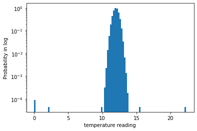

```python
a=[10., 10.3, 2.1, 0., 0., 15.6, 22.3, 12.7]
data=stats.norm.rvs(loc = 12., scale = 0.4, size = 100000)
full = np.append(data, a)
fig, ax = plt.subplots(1, 1)
ax.hist(d,100, density=True)
plt.xlabel("temperature reading")
plt.ylabel("Probability in log")
plt.yscale('log')
#x = np.linspace(4.95,5.05,1000)
#ax.plot(x,stats.norm.pdf(x,loc = 5., scale = 0.01),linewidth = 8,alpha = 0.7)
plt.show()
```

A2:QUESTION : What data point are within 5σ of the background distribution? The reason I choose this question is because this is the real data we keep that doesn't contain any anomalous read.

A3:Calculate the data inside the 5σ

A4:Truth table:

```python
X = np.sort(full)
D = np.array([])
D_1 = np.array([])

def truthtable(s):
    sigma = stats.norm.sf(s)
    maxTemp = stats.norm.isf(sigma, loc=12, scale=0.4)
    minTemp = stats.norm.isf(1-sigma, loc=12, scale=0.4)
    D = X[np.logical_and(X > minTemp, X < maxTemp)]
    D_1 = X[np.logical_or(X < minTemp, X > maxTemp)]
    TP = sum((Counter(data) & Counter(D)).values())
    FP = sum((Counter(D) & Counter(a)).values())
    TN = sum((Counter(data) & Counter(D_1)).values())
    FN = sum((Counter(D_1) & Counter(a)).values())

    table = pd.DataFrame(data=[[TP,FP],[TN,FN]],
                     index=["Pos", "Neg"],
                     columns=["True", "False"])
    return table
```

```python
truthtable(5)
```

|  | True | False |
| --- | --- | --- |
| Pos | 100000 | 2 |
| Neg | 0 | 6 |

There are two mistakes(12.7 and 10.3) , if we included all data at greater than 5 sigma significance there would be more FP less TN less FN

B:Counstruct truth table for different threshold

```python
truthtable(3)
```

|  | True | False |
| --- | --- | --- |
| Pos | 99719 | 1 |
| Neg | 281 | 7 |

```python
truthtable(7)
```

|  | True | False |
| --- | --- | --- |
| Pos | 100000 | 3 |
| Neg | 0 | 5 |

```python
sigma = stats.norm.isf(stats.norm.sf(12.7, scale=0.4, loc=12))
truthtable(sigma)
sigma
```

```
1.7499999999999984
```

2.

"What recorded temperature value on the thermal device is five sigmas or more from the mean so that we can get rid of these points of data? In more detail, at which x value of temperature in the new distribution (with 'bad data') is the probability of getting the temperature larger than the probability of five sigma to the right of the mean or less than the probability of five sigma to the left of the mean in a normal distribution?" We do this by finding the integral under the distribution we analyze at x that yields the same or less probability than 5 sigma on a normal distribution. We could search for five sigma of our new dataset by searching all values larger or less than the mean +- stdev * 5 but this doesn't neccessarily give us the probability of five sigma in a normal distribution which is what we're looking for. This method only works for a normal distribution and for any other distribution it would not work. This is my question because I am essentially asking "Which data points have a probability larger or less than 5 sigma?" in order to determine which of the data points are "bad data" and thus worthy of removing. We are using 5 sigma as a base line because the probability of 5 sigma or higher is about 1 in 3.5 million which is reasonable cause to see the data point as an outlier. We also use this baseline because if we go any lower we may be recieving too many false positives and thus losing out on good data. There is discussion to be had whether its better to have more false positives but less true negative or vice versa but we decided it is better to have less false positives and more true negatives.

3.

```
13.99999999998807
10.00000000001193
100002
```

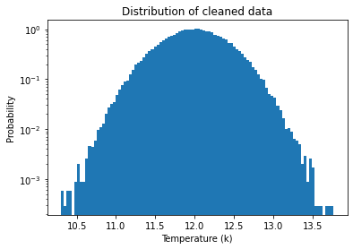

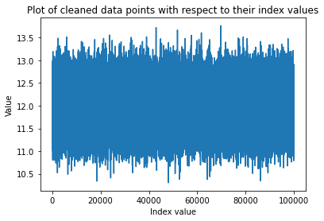

```python
fiveSigma = 1 - stats.norm.cdf(5)
xTop = stats.norm.ppf(1 - fiveSigma, mu, std)
xBot = stats.norm.ppf(fiveSigma, mu, std)
print(xTop)
print(xBot)

for i in reversed(range(len(d))):
    if d[i] > xTop:
        d = np.delete(d, i)
    if d[i] < xBot:
        d = np.delete(d, i)
print(len(d))
plt.hist(d, 100, density=True)
plt.yscale('log')
plt.title('Distribution of cleaned data')
plt.xlabel('Temperature (k)')
plt.ylabel('Probability')
plt.show()
x = list(range(len(d)))
plt.title('Plot of cleaned data points with respect to their index values')
plt.xlabel('Index value')
plt.ylabel('Value')
plt.plot(x, d)
```

First we calculated the 5 sigma probability of a normal distribution and then we calculated the ppf, of a normal distribution with the adjusted mean of 12 and standard deviation of .4.

B

C

For sure that there arr some bad datas getting in. How muc they affect the result is depends on the threshold of our data system. They are unavoidable, since it can by lower by lowering (making more sensitive) our statistical threshold but this comes at the cost of potentially more omissions.

# problem 2

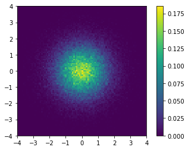

```python
dist = stats.norm(scale=1)
a = dist.rvs((2, 100_000))

plt.hist2d(a[0, :], a[1, :], bins=100, density=True)
plt.colorbar()
plt.xlim(-4, 4)
plt.ylim(-4, 4)
plt.xticks(range(-4, 5))
plt.yticks(range(-4, 5))
plt.gca().set_aspect('equal', 'box')
```

1

We wounder the distance in arcseconds of a '5 sigma' detection of movement. Thus we are looking for the distance a potential asteroid must travel to be considered an asteroid. Thus, "What distance away from the origin would confirm a potential asteroid as an asteroid. Or more mathematically, in a 2D Gaussian with 1 arcsecond RMS with a significance sensitivity of 5 sigma, at what distance foes a potential asteroid reach 5 sigma away from average and is thus not considered an asteroid?

2

What is the distance away from the origin at which the 2-dimensional Gaussian background might produce a position measurement that has a significance of $5\sigma$?

3

```python
dist_2d = stats.rayleigh(scale=1)
distance = dist_2d.ppf(dist.cdf(5))
pdf_2d = lambda r: r*np.exp(-r**2 / 2)
value, error = sp.integrate.quad(pdf_2d, distance, np.inf)
print(f"Distance for 5 sigma: {distance} arc-seconds")
print(f"Converting back to sigma: {dist.ppf(1 - value)}")
```

```
Distance for 5 sigma: 5.489079776034238 arc-seconds
Converting back to sigma: 4.999999996908459
```

# problem 3

1

Is that safe to say that a moon is blocking cosmic rays from reaching earth if we have observed 6800 cosmic rays over 15 days? What is the probability of observing 6800 cosmic rays or within 15 days? Will the calculation based on the distribution of expected cosmic rays observed of 1 cosmic ray per minute?

2

What's the probability if we set mu = 1 (cosmic ray / minute) (60 minutes / hour) 8(hour / day) * 15 (days) = 7200, and k = P(k <= 6800) ?

```python
k = 6800
mu = 7200
prob = stats.poisson.cdf(k, mu)
print("Probability of 6800 rays or less: " + str(prob))
```

```
Probability of 6800 rays or less: 1.0133280183917768e-06
```

3

```python
sig = stats.norm.ppf(prob)
print("Sigma of 6800: " + str(sig))
print("Magnitude of sigma: " + str(abs(sig)))
```

```
Sigma of 6800: -4.750747965777188
Magnitude of sigma: 4.750747965777188
```

the sigma value is less than 5